```python
import pandas as pd
import numpy as np
import matplotlib.pyplot as plt
from sklearn.model_selection import train_test_split
from sklearn.compose import ColumnTransformer
from sklearn.pipeline import Pipeline
from sklearn.impute import SimpleImputer
from sklearn.preprocessing import OneHotEncoder
from sklearn.metrics import roc_auc_score
from xgboost import XGBClassifier
from sklearn.ensemble import RandomForestRegressor
from sklearn.metrics import mean_absolute_error, r2_score
```

# 1. Cel projektu

Celem projektu jest zbudowanie modelu ryzyka kredytowego poprzez estymację:

- PD (Probability of Default),
- LGD (Loss Given Default),
- EAD (Exposure at Default),
- EL (Expected Loss).

Projekt wykorzystuje dane Lending Club i nawiązuje do podejścia IRB stosowanego w bankowości.

# 2. Wczytanie danych

```python
dane = pd.read_csv("dane/loan.csv", low_memory=False)
dane.head()
```

|  | id | member_id | loan_amnt | funded_amnt | funded_amnt_inv | term | int_rate | installment | grade | sub_grade | emp_title | emp_length | home_ownership | annual_inc | verification_status | issue_d | loan_status | pymnt_plan | url | desc | purpose | title | zip_code | addr_state | dti | delinq_2yrs | earliest_cr_line | inq_last_6mths | mths_since_last_delinq | … |
| --- | --- | --- | --- | --- | --- | --- | --- | --- | --- | --- | --- | --- | --- | --- | --- | --- | --- | --- | --- | --- | --- | --- | --- | --- | --- | --- | --- | --- | --- | --- |
| 0 | NaN | NaN | 2500 | 2500 | 2500.0 | 36 months | 13.56 | 84.92 | C | C1 | Chef | 10+ years | RENT | 55000.0 | Not Verified | Dec-2018 | Current | n | NaN | NaN | debt_consolidation | Debt consolidation | 109xx | NY | 18.24 | 0.0 | Apr-2001 | 1.0 | NaN | … |
| 1 | NaN | NaN | 30000 | 30000 | 30000.0 | 60 months | 18.94 | 777.23 | D | D2 | Postmaster | 10+ years | MORTGAGE | 90000.0 | Source Verified | Dec-2018 | Current | n | NaN | NaN | debt_consolidation | Debt consolidation | 713xx | LA | 26.52 | 0.0 | Jun-1987 | 0.0 | 71.0 | … |
| 2 | NaN | NaN | 5000 | 5000 | 5000.0 | 36 months | 17.97 | 180.69 | D | D1 | Administrative | 6 years | MORTGAGE | 59280.0 | Source Verified | Dec-2018 | Current | n | NaN | NaN | debt_consolidation | Debt consolidation | 490xx | MI | 10.51 | 0.0 | Apr-2011 | 0.0 | NaN | … |
| 3 | NaN | NaN | 4000 | 4000 | 4000.0 | 36 months | 18.94 | 146.51 | D | D2 | IT Supervisor | 10+ years | MORTGAGE | 92000.0 | Source Verified | Dec-2018 | Current | n | NaN | NaN | debt_consolidation | Debt consolidation | 985xx | WA | 16.74 | 0.0 | Feb-2006 | 0.0 | NaN | … |
| 4 | NaN | NaN | 30000 | 30000 | 30000.0 | 60 months | 16.14 | 731.78 | C | C4 | Mechanic | 10+ years | MORTGAGE | 57250.0 | Not Verified | Dec-2018 | Current | n | NaN | NaN | debt_consolidation | Debt consolidation | 212xx | MD | 26.35 | 0.0 | Dec-2000 | 0.0 | NaN | … |

# 3. Przygotowanie targetu (PD)

Do analizy wybrano wyłącznie kredyty o zakończonym cyklu życia, aby uniknąć niejednoznaczności związanej z aktywnymi zobowiązaniami. W szczególności:

- jako **default (1)** oznaczono kredyty ze statusem:
  - `Charged Off`,
  - `Default`,
  - `Does not meet the credit policy. Status:Charged Off`,
- jako **brak defaultu (0)** oznaczono kredyty ze statusem:
  - `Fully Paid`,
  - `Does not meet the credit policy. Status:Fully Paid`.

Z analizy wykluczono kredyty o statusie:

- `Current`,
- `Late`,
- `In Grace Period`,

ponieważ nie mają one jeszcze ostatecznego wyniku (mogą w przyszłości zostać spłacone lub zdefaultować).

Na tej podstawie utworzono binarną zmienną `czy_default`, która stanowi target modelu PD.

```python
status_default = [
    "Charged Off",
    "Default",
    "Does not meet the credit policy. Status:Charged Off"
]

status_ok = [
    "Fully Paid",
    "Does not meet the credit policy. Status:Fully Paid"
]

dane_model = dane[dane["loan_status"].isin(status_default + status_ok)].copy()
dane_model["czy_default"] = dane_model["loan_status"].isin(status_default).astype(int)
dane_model["czy_default"].value_counts(normalize=True)
```

```
czy_default
0    0.799105
1    0.200895
Name: proportion, dtype: float64
```

Udział defaultów w próbie wynosi około **20%**

# 4. EAD i LGD

W kolejnym kroku wyznaczono dwa kluczowe parametry ryzyka kredytowego:  
**EAD (Exposure at Default)** oraz **LGD (Loss Given Default)**.

### EAD

Ekspozycja w momencie defaultu (EAD) została przybliżona jako kwota finansowania kredytu:

EAD = funded_amnt (rzeczywista kwota, którą inwestorzy wypłacili klientowi)

Przyjęcie tej wartości jest uzasadnione, ponieważ w momencie udzielenia kredytu stanowi ona maksymalną ekspozycję banku na klienta.

### LGD

LGD określa, jaka część ekspozycji nie zostaje odzyskana po defaultcie.  
Została wyznaczona na podstawie rzeczywistych danych o odzyskach (`recoveries - kwota odzyskana po defaultcie kredytu`):

stopa_odzysku = recoveries / EAD  
LGD = 1 − stopa_odzysku

### Dane do modelu LGD

Model LGD estymowano wyłącznie na obserwacjach, dla których wystąpił default (`czy_default = 1`).

```python
# EAD
dane_model["EAD"] = dane_model["funded_amnt"]

# LGD
dane_model["stopa_odzysku"] = dane_model["recoveries"] / dane_model["EAD"]
dane_model["stopa_odzysku"] = dane_model["stopa_odzysku"].clip(0, 1)

dane_model["LGD"] = 1 - dane_model["stopa_odzysku"]

# tylko defaulty do modelu LGD
dane_lgd = dane_model[dane_model["czy_default"] == 1].copy()
```

# 5. Model PD

W kolejnym kroku zbudowano model predykcyjny służący do estymacji prawdopodobieństwa defaultu (PD).

### Wybór zmiennych

Do modelu wykorzystano zmienne opisujące sytuację finansową klienta, charakterystykę kredytu oraz historię kredytową, m.in.:

- kwota kredytu (`loan_amnt`, `funded_amnt`),
- oprocentowanie (`int_rate`),
- wysokość raty (`installment`),
- rating kredytowy (`grade`, `sub_grade`),
- dochód klienta (`annual_inc`),
- wskaźnik zadłużenia (`dti`),
- historia kredytowa (`delinq_2yrs`, `inq_last_6mths`, `total_acc`),
- wykorzystanie kredytu (`revol_bal`, `revol_util`).

Wybrane zmienne są dostępne na moment udzielenia kredytu, co zapobiega wykorzystaniu informacji przyszłych.

### Przygotowanie danych

Dane zostały oczyszczone poprzez:

- zamianę wartości nieskończonych na brakujące,
- usunięcie obserwacji z brakującymi wartościami.

Zbiór danych podzielono na część treningową i testową (80/20), z zachowaniem proporcji klas.

### Przetwarzanie zmiennych

Zastosowano pipeline obejmujący:

- imputację braków:
  - medianą dla zmiennych numerycznych,
  - najczęstszą wartością dla zmiennych kategorycznych,
- kodowanie zmiennych kategorycznych przy użyciu One-Hot Encoding.

### Model

Do estymacji PD wykorzystano model **XGBoost (Extreme Gradient Boosting)**, który dobrze radzi sobie z nieliniowościami oraz interakcjami między zmiennymi.

### Ocena modelu

Jako miarę jakości modelu zastosowano:

- **AUC (Area Under Curve)** (jak dobrze model PD odróżnia kredyty, które zdefaultują, od tych spłaconych poprawnie),
- **Gini coefficient** (klientów dobrych vs klientów, którzy zdefaultują).

Uzyskany wynik:

- AUC ≈ 0.72,
- Gini ≈ 0.43,

wskazuje na dobrą zdolność modelu do rozróżniania klientów ryzykownych od bezpiecznych.

```python
zmienne_pd = [
    "loan_amnt", "funded_amnt", "term", "int_rate", "installment",
    "grade", "sub_grade", "annual_inc", "verification_status",
    "dti", "delinq_2yrs", "inq_last_6mths",
    "open_acc", "pub_rec", "revol_bal", "revol_util", "total_acc"
]

dane_pd = dane_model[zmienne_pd + ["czy_default"]].replace([np.inf, -np.inf], np.nan).dropna()

X = dane_pd[zmienne_pd]
y = dane_pd["czy_default"]

X_train, X_test, y_train, y_test = train_test_split(
    X, y, test_size=0.2, random_state=42, stratify=y
)

num = X.select_dtypes(include=["int64", "float64"]).columns
cat = X.select_dtypes(include=["object"]).columns

preprocessing = ColumnTransformer([
    ("num", SimpleImputer(strategy="median"), num),
    ("cat", Pipeline([
        ("imp", SimpleImputer(strategy="most_frequent")),
        ("enc", OneHotEncoder(handle_unknown="ignore"))
    ]), cat)
])

model_pd = Pipeline([
    ("prep", preprocessing),
    ("xgb", XGBClassifier(
        n_estimators=300,
        max_depth=4,
        learning_rate=0.05,
        subsample=0.8,
        colsample_bytree=0.8,
        random_state=42,
        eval_metric="logloss"
    ))
])

model_pd.fit(X_train, y_train)

PD = model_pd.predict_proba(X_test)[:, 1]

auc = roc_auc_score(y_test, PD)
gini = 2 * auc - 1

auc, gini
```

```
(0.7161642523214926, 0.4323285046429852)
```

# 6. Model LGD

W kolejnym etapie zbudowano model estymujący stratę w przypadku defaultu (LGD).

### Przygotowanie danych

Model LGD został zbudowany wyłącznie na obserwacjach, dla których wystąpił default (`czy_default = 1`).  
Jest to zgodne z definicją LGD, ponieważ strata może być zaobserwowana tylko dla niespłaconych kredytów.

Jako zmienną objaśnianą przyjęto:

- `LGD` – wyliczoną wcześniej na podstawie rzeczywistych odzysków.

### Wybór zmiennych

Do modelu wykorzystano zmienne finansowe oraz kredytowe klienta, m.in.:

- kwotę kredytu (`loan_amnt`, `funded_amnt`),
- oprocentowanie (`int_rate`),
- wysokość raty (`installment`),
- dochód (`annual_inc`),
- wskaźnik zadłużenia (`dti`),
- wykorzystanie kredytu (`revol_bal`, `revol_util`),
- historię kredytową (`total_acc`).

Zmienne te mogą wpływać na poziom odzysku środków po defaultcie.

### Model

Do estymacji LGD zastosowano model **Random Forest Regressor**, który:

- dobrze radzi sobie z nieliniowościami,
- nie wymaga silnych założeń dotyczących rozkładu zmiennej,
- jest odporny na outliery.

W pipeline zastosowano imputację braków medianą dla zmiennych numerycznych.

### Ocena modelu

Model oceniono przy użyciu:

- **MAE (Mean Absolute Error)** – średni błąd bezwzględny,
- **R² (współczynnik determinacji)**.

Uzyskane wyniki:

- MAE ≈ 0.063,
- R² ≈ 0.013.

### Interpretacja wyników

Niski błąd MAE wskazuje, że model stosunkowo dobrze przewiduje poziom LGD w sensie średniego błędu.

Jednocześnie bardzo niska wartość R² oznacza, że model wyjaśnia niewielką część zmienności LGD.  
Jest to jednak typowe dla LGD, które w praktyce jest zmienną trudną do modelowania i często charakteryzuje się dużą losowością.

```python
zmienne_lgd = [
    "loan_amnt", "funded_amnt", "int_rate",
    "installment", "annual_inc", "dti",
    "revol_bal", "revol_util", "total_acc"
]

X_lgd = dane_lgd[zmienne_lgd]
y_lgd = dane_lgd["LGD"]

X_train_lgd, X_test_lgd, y_train_lgd, y_test_lgd = train_test_split(
    X_lgd, y_lgd, test_size=0.2, random_state=42
)

model_lgd = Pipeline([
    ("imp", SimpleImputer(strategy="median")),
    ("rf", RandomForestRegressor(
        n_estimators=200,
        max_depth=6,
        random_state=42
    ))
])

model_lgd.fit(X_train_lgd, y_train_lgd)

LGD_pred = model_lgd.predict(X_test_lgd)

mae = mean_absolute_error(y_test_lgd, LGD_pred)
r2 = r2_score(y_test_lgd, LGD_pred)

mae, r2
```

```
(0.06300879255787183, 0.012784538916558952)
```

# 7. Expected Loss (EL)

W ostatnim etapie projektu połączono trzy kluczowe komponenty ryzyka kredytowego:

- PD (Probability of Default),
- LGD (Loss Given Default),
- EAD (Exposure at Default),

w celu wyznaczenia oczekiwanej straty, definiowana jest jako:

EL = PD × LGD × EAD

### Implementacja

Dla każdej obserwacji w zbiorze testowym:

- przypisano predykcję PD z modelu klasyfikacyjnego,
- wyznaczono LGD przy użyciu modelu regresyjnego,
- przyjęto EAD jako wartość `funded_amnt`.

### Interpretacja

Expected Loss reprezentuje średnią oczekiwaną stratę z danego kredytu, uwzględniając zarówno prawdopodobieństwo niewypłacalności, jak i potencjalną wielkość straty.

W praktyce bankowej EL wykorzystywana jest do:

- wyceny ryzyka kredytowego,
- ustalania rezerw,
- zarządzania portfelem kredytowym.

```python
wyniki = X_test.copy()

wyniki["PD"] = PD

wyniki["LGD"] = model_lgd.predict(X_test[zmienne_lgd])
wyniki["LGD"] = wyniki["LGD"].clip(0, 1)

wyniki["EAD"] = X_test["funded_amnt"]

wyniki["EL"] = wyniki["PD"] * wyniki["LGD"] * wyniki["EAD"]
```

# 8. Analiza portfela

Ważność zmiennych została wyznaczona na podstawie miary istotności wykorzystywanej przez model gradient boosting, która odzwierciedla wpływ danej zmiennej na poprawę jakości predykcji.

### Najważniejsze zmienne

Do najistotniejszych predyktorów ryzyka kredytowego należą:

- **rating kredytowy (`grade`)** – szczególnie klasa A, B, C,
- **oprocentowanie (`int_rate`)**,
- **okres kredytowania (`term`)**,
- **szczegółowy rating (`sub_grade`)**,
- **status weryfikacji dochodu (`verification_status`)**,
- **wskaźnik zadłużenia (`dti`)**.

Największe znaczenie ma zmienna `grade`, która jest wewnętrzną oceną ryzyka przypisaną przez Lending Club. Wysoka ważność tej zmiennej wskazuje, że model w dużym stopniu opiera się na już istniejącym systemie scoringowym.Oprocentowanie (`int_rate`) również silnie wpływa na ryzyko — wyższe oprocentowanie jest zazwyczaj związane z wyższym ryzykiem kredytowym. Zmienna `term` wskazuje, że dłuższe kredyty są bardziej ryzykowne, co jest zgodne z intuicją finansową.

```python
model_xgb = model_pd.named_steps["xgb"]
nazwy_cech = model_pd.named_steps["prep"].get_feature_names_out()

waznosc = pd.DataFrame({
    "zmienna": nazwy_cech,
    "waznosc": model_xgb.feature_importances_
}).sort_values("waznosc", ascending=False)

waznosc.head(15)
```

|  | zmienna | waznosc |
| --- | --- | --- |
| 15 | cat__grade_A | 0.338671 |
| 2 | num__int_rate | 0.107483 |
| 16 | cat__grade_B | 0.103637 |
| 17 | cat__grade_C | 0.062617 |
| 18 | cat__grade_D | 0.044947 |
| 13 | cat__term_ 36 months | 0.039982 |
| 14 | cat__term_ 60 months | 0.036264 |
| 57 | cat__verification_status_Not Verified | 0.024419 |
| 30 | cat__sub_grade_B4 | 0.019271 |
| 31 | cat__sub_grade_B5 | 0.016324 |
| 33 | cat__sub_grade_C2 | 0.014570 |
| 26 | cat__sub_grade_A5 | 0.014079 |
| 5 | num__dti | 0.013222 |
| 32 | cat__sub_grade_C1 | 0.009902 |
| 22 | cat__sub_grade_A1 | 0.009013 |

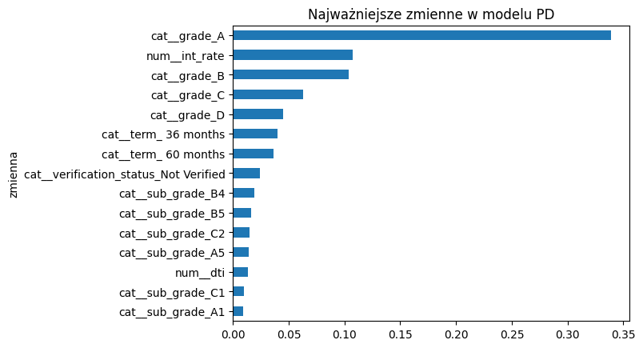

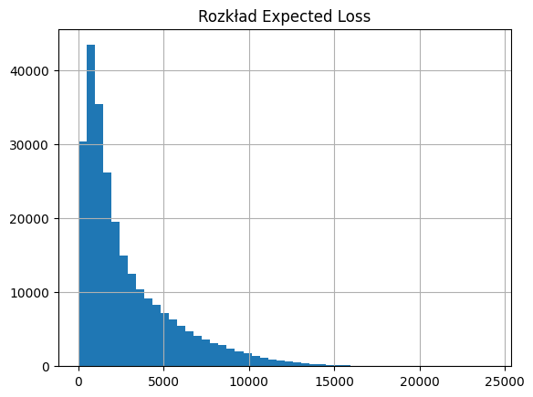

```python
waznosc.head(15).sort_values("waznosc").plot(
    x="zmienna", y="waznosc", kind="barh", legend=False
)
plt.title("Najważniejsze zmienne w modelu PD")
plt.show()

wyniki["EL"].hist(bins=50)
plt.title("Rozkład Expected Loss")
plt.show()
```